# Evaluación de la dieta en mortalidad total del Salmón del Atlántico

Constanza Pino Ajenjo

2022-06-26

##Introducción

**Descripción del problema a resolver:**

Debido a su impacto en la salud de Salmón del Atlántico, es importante analizar la influencia de dos tipos de dietas en la mortalidad en los centros de cultivo en agua de mar.

##Introducción

- número de ingreso de peces (Ingreso)
- peso promedio de los peces cosechados en kilogramos (Peso_cosecha)
- número de mortalidad total (Mortalidad)

##Introducción

**Hipótesis:**

- Hipótesis nula (H0): los dos tipos de Dieta son iguales en la mortalidad de Salmón del Atlántico.
- Hipotesis alternativa (H1): los dos tipos de Dieta son distintos en la mortalidad de Salmón del Atlántico.

**Tablas de resumen:** En la tabla 1 se muestra la base de datos que se utiliza en este trabajo y, luego, en la tabla 2 está un resumen de estadística descriptiva.

```r
#Generar una tabla con la base de datos de Dieta con función datatable:
DT::datatable(Dieta,caption="Tabla 1. Base de datos de tipo de dieta, número de peces ingresados, peso cosecha y número de mortalidad total por Unidad")
```

|  | Unidad | Dieta | Ingreso | Peso_cosecha | Mortalidad |
| --- | --- | --- | --- | --- | --- |
| 1 | 1 | BES1 | 83334 | 5.3 | 6748 |
| 2 | 2 | BES1 | 83044 | 4.9 | 5850 |
| 3 | 3 | BES1 | 83333 | 5.3 | 8116 |
| 4 | 4 | BES1 | 83622 | 5 | 4632 |
| 5 | 5 | BES1 | 83334 | 5.7 | 12765 |
| 6 | 6 | BES1 | 83150 | 5.2 | 10187 |
| 7 | 7 | BES1 | 83333 | 4.6 | 7896 |
| 8 | 8 | BES1 | 83516 | 5.3 | 8721 |
| 9 | 9 | BES1 | 83334 | 5.4 | 7434 |
| 10 | 10 | BES1 | 82300 | 5.4 | 8876 |

[output cut: 128 more lines]

```r
#Resumen de estadística descriptiva con función pander:
pander(summary(Dieta,caption="Tabla 2. Resumen data frame"))
```

| Unidad | Dieta | Ingreso | Peso_cosecha | Mortalidad |
| --- | --- | --- | --- | --- |
| 1 : 1 | BES1:71 | Min. : 59711 | Min. :0.000 | Min. : 4632 |
| 2 : 1 | BS1 :67 | 1st Qu.: 80578 | 1st Qu.:4.725 | 1st Qu.: 9689 |
| 3 : 1 | NA | Median : 87500 | Median :5.200 | Median :15367 |
| 4 : 1 | NA | Mean : 86930 | Mean :5.163 | Mean :17281 |
| 5 : 1 | NA | 3rd Qu.: 96275 | 3rd Qu.:5.600 | 3rd Qu.:21090 |
| 6 : 1 | NA | Max. :105438 | Max. :6.300 | Max. :48484 |
| (Other):132 | NA | NA | NA | NA |

**Gráficos de histogramas y boxplot:** Se describe la variación de cada variable de estudio usando histogramas y boxplot. En la Figura 1 se muestran los histogramas de ingreso, peso cosecha y mortalidad total. Mientras que en la Figura 2 y 3 se muestran los boxplot de las mismas variables por Unidad y tipo de Dieta respectivamente.

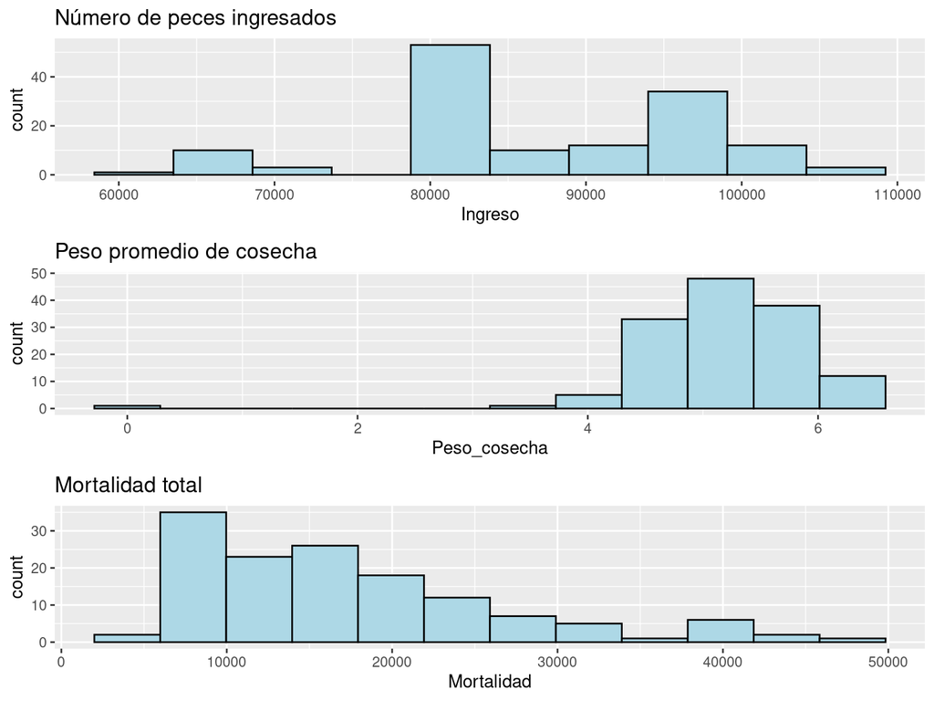

```r
#Observar el comportamiento de las variables en estudio usando histogramas y boxplot (valor atípico se muestra en punto de color rojo):

hist_ing <- ggplot(Dieta,aes(Ingreso))+
  geom_histogram(fill="lightblue",color="black",bins=10)+
  labs(title = "Número de peces ingresados")

hist_peso <- ggplot(Dieta,aes(Peso_cosecha))+
  geom_histogram(fill="lightblue",color="black",bins=12)+
  labs(title = "Peso promedio de cosecha")

hist_mort <- ggplot(Dieta,aes(Mortalidad))+
  geom_histogram(fill="lightblue",color="black",bins=12)+
  labs(title = "Mortalidad total")

grid.arrange(hist_ing, hist_peso, hist_mort, ncol=1, nrow =3)
```

Figura 1.

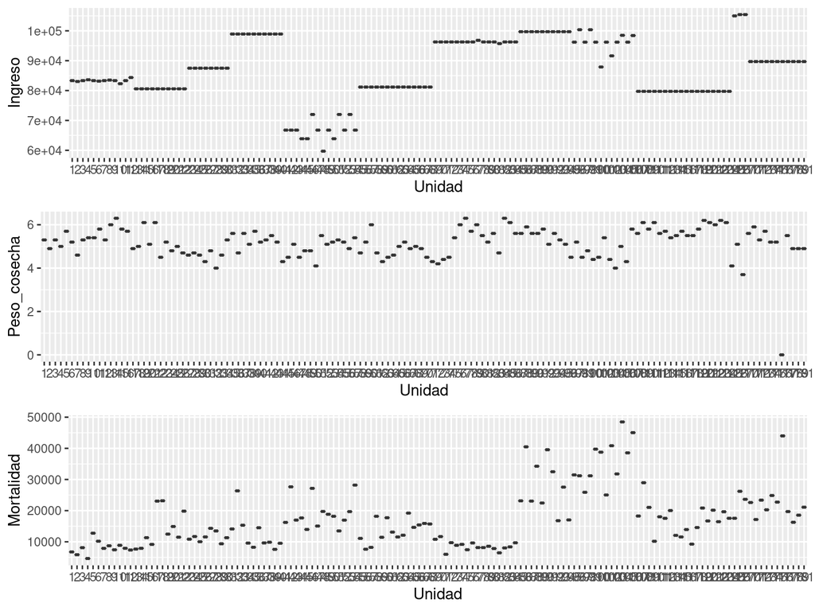

```r
bi <-ggplot(data=Dieta, aes(x=Unidad,y=Ingreso))+geom_boxplot()
bp <-ggplot(data=Dieta, aes(x=Unidad,y=Peso_cosecha))+geom_boxplot()
bm <-ggplot(data=Dieta, aes(x=Unidad,y=Mortalidad))+geom_boxplot()

grid.arrange(bi, bp, bm, ncol=1, nrow =3)
```

Figura 2.

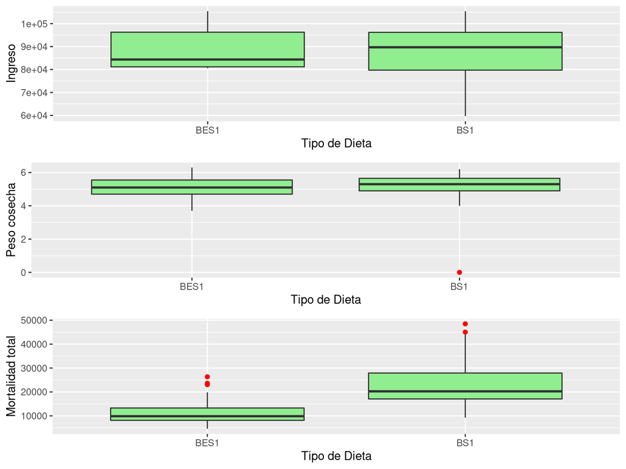

```r
blot_ing <- ggplot(Dieta,aes(y=Ingreso,x=Dieta))+
  geom_boxplot(fill="lightgreen",outlier.colour = "red")+
  labs(y="Ingreso",x="Tipo de Dieta")

blot_peso <- ggplot(Dieta,aes(y=Peso_cosecha,x=Dieta))+
  geom_boxplot(fill="lightgreen",outlier.colour = "red")+
  labs(y="Peso cosecha",x="Tipo de Dieta")

blot_mort <- ggplot(Dieta,aes(y=Mortalidad,x=Dieta))+
  geom_boxplot(fill="lightgreen",outlier.colour = "red")+
  labs(y="Mortalidad total",x="Tipo de Dieta")

grid.arrange(blot_ing, blot_peso, blot_mort, ncol=1, nrow =3)
```

Figura 3.

**Gráficos de interacción:** En las siguientes figuras se muestran los gráficos de interacción entre cada variable cuantitativa y los factores Unidad y Dieta.

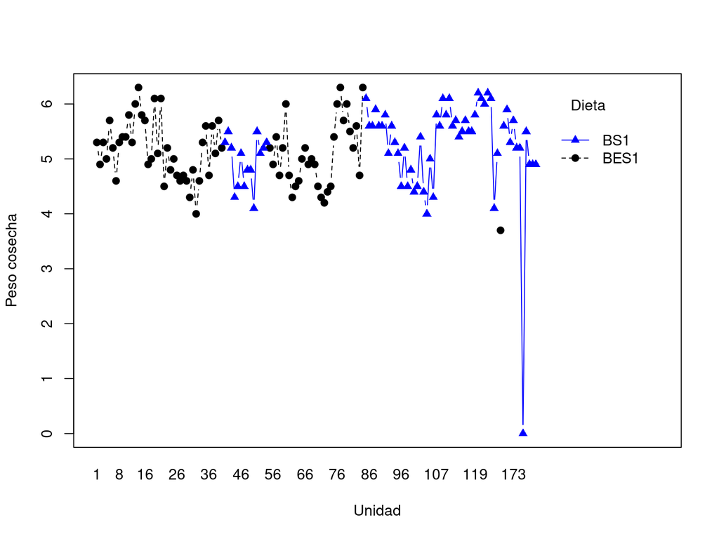

```r
#Establecer relación entre variables cuantitativas y factores usando gráficas de correlación, boxplot, interacción o de tamaño de los efectos:

ip1 <- interaction.plot(Dieta$Unidad,Dieta$Dieta, Dieta$Peso_cosecha,trace.label="Dieta",fun=mean, xlab="Unidad",ylab="Peso cosecha",type="b", col= c("black", "blue"),pch=c(19,17))
```

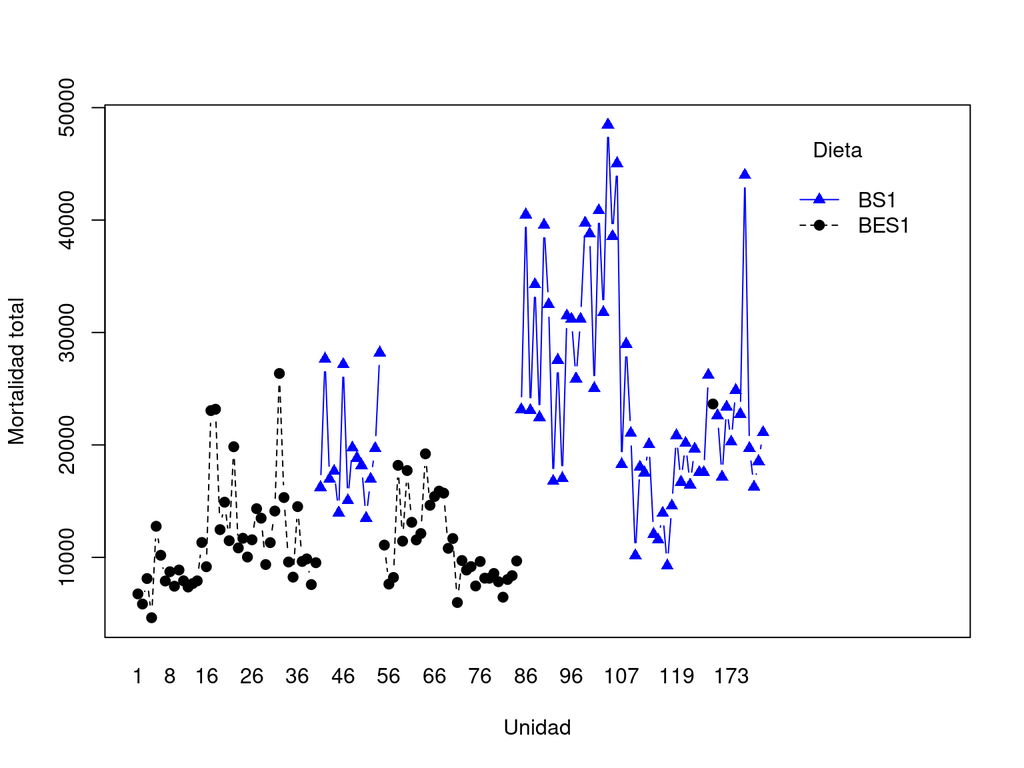

```r
ip2 <- interaction.plot(Dieta$Unidad,Dieta$Dieta, Dieta$Mortalidad,trace.label="Dieta",fun=mean,xlab="Unidad",ylab="Mortalidad total",type="b", col= c("black", "blue"),pch=c(19,17))
```

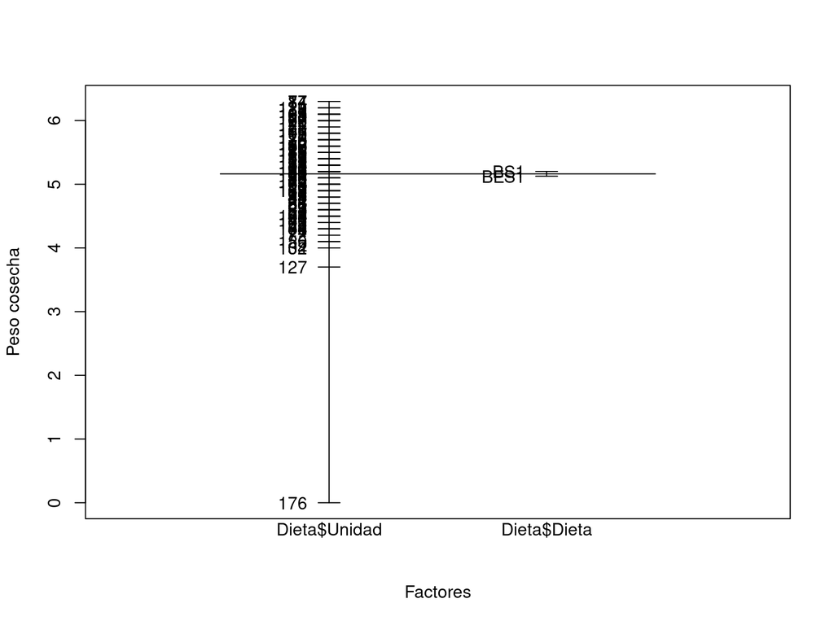

```r
id1 <- plot.design(Dieta$Peso_cosecha~Dieta$Unidad*Dieta$Dieta,xlab="Factores", ylab="Peso cosecha")
```

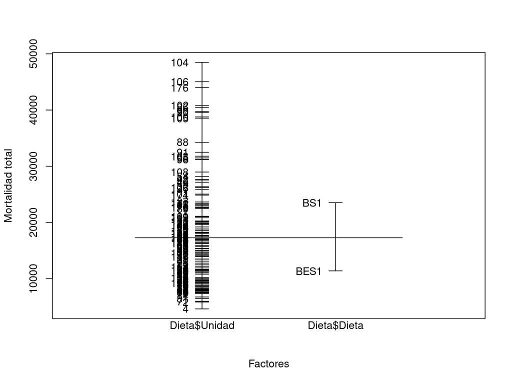

```r
id2 <- plot.design(Dieta$Mortalidad~Dieta$Unidad*Dieta$Dieta,xlab="Factores", ylab="Mortalidad total")
```